# Final Project - Macia - 3 - Logistic Regression

Maçià Bartomeu Llabrés Ferrer

2023-01-22

We start by loading the previous “prep” file and check if the data is the same.

```r
df <- read.csv("FPdata_PREP.csv", stringsAsFactors = TRUE)
str(df)
```

```
## 'data.frame':    426043 obs. of  40 variables:
##  $ State                    : int  1 1 1 1 1 1 1 1 1 1 ...
##  $ Gender                   : int  0 0 0 0 0 1 0 0 0 0 ...
##  $ GeneralHealth            : int  4 5 4 5 2 1 4 3 3 3 ...
##  $ PhysicalHealthDays       : int  0 0 2 0 2 1 0 0 0 1 ...
##  $ MentalHealthDays         : int  0 0 3 0 0 0 0 0 0 0 ...
##  $ LastCheckupTime          : int  5 1 5 5 5 5 5 5 5 5 ...
##  $ PhysicalActivities       : int  0 0 1 1 1 0 1 0 1 1 ...
##  $ SleepHours               : int  8 6 5 7 9 7 7 8 6 7 ...
##  $ RemovedTeeth             : int  1 1 1 1 1 1 1 1 1 1 ...
##  $ HadHeartAttack           : int  0 0 0 0 0 1 0 0 0 0 ...
##  $ HadAngina                : int  0 0 0 0 0 0 0 0 0 0 ...
##  $ HadStroke                : int  0 0 0 0 0 1 0 0 0 0 ...
##  $ HadAsthma                : int  0 0 0 1 0 0 0 0 0 0 ...
##  $ HadSkinCancer            : int  0 1 1 0 0 0 0 0 1 0 ...
```

[output cut: 26 more lines]

```r
summary(df)
```

```
##      State          Gender       GeneralHealth   PhysicalHealthDays
##  Min.   : 1.0   Min.   :0.0000   Min.   :1.000   Min.   : 0.000
##  1st Qu.:16.0   1st Qu.:0.0000   1st Qu.:3.000   1st Qu.: 0.000
##  Median :27.0   Median :0.0000   Median :4.000   Median : 0.000
##  Mean   :28.4   Mean   :0.4745   Mean   :3.466   Mean   : 4.076
##  3rd Qu.:43.0   3rd Qu.:1.0000   3rd Qu.:4.000   3rd Qu.: 3.000
##  Max.   :54.0   Max.   :1.0000   Max.   :5.000   Max.   :30.000
##  MentalHealthDays LastCheckupTime PhysicalActivities   SleepHours
##  Min.   : 0.000   Min.   :1.000   Min.   :0.0000     Min.   : 1.000
##  1st Qu.: 0.000   1st Qu.:5.000   1st Qu.:1.0000     1st Qu.: 6.000
##  Median : 0.000   Median :5.000   Median :1.0000     Median : 7.000
##  Mean   : 4.158   Mean   :4.548   Mean   :0.7697     Mean   : 7.031
##  3rd Qu.: 4.000   3rd Qu.:5.000   3rd Qu.:1.0000     3rd Qu.: 8.000
##  Max.   :30.000   Max.   :5.000   Max.   :1.0000     Max.   :24.000
##   RemovedTeeth    HadHeartAttack      HadAngina         HadStroke
##  Min.   :0.0000   Min.   :0.00000   Min.   :0.00000   Min.   :0.00000
##  1st Qu.:0.0000   1st Qu.:0.00000   1st Qu.:0.00000   1st Qu.:0.00000
##  Median :0.0000   Median :0.00000   Median :0.00000   Median :0.00000
##  Mean   :0.4712   Mean   :0.05596   Mean   :0.05893   Mean   :0.04286
##  3rd Qu.:1.0000   3rd Qu.:0.00000   3rd Qu.:0.00000   3rd Qu.:0.00000
##  Max.   :1.0000   Max.   :1.00000   Max.   :1.00000   Max.   :1.00000
##    HadAsthma     HadSkinCancer        HadCOPD        HadDepressiveDisorder
##  Min.   :0.000   Min.   :0.00000   Min.   :0.00000   Min.   :0.0000
##  1st Qu.:0.000   1st Qu.:0.00000   1st Qu.:0.00000   1st Qu.:0.0000
##  Median :0.000   Median :0.00000   Median :0.00000   Median :0.0000
##  Mean   :0.144   Mean   :0.08114   Mean   :0.07712   Mean   :0.1981
##  3rd Qu.:0.000   3rd Qu.:0.00000   3rd Qu.:0.00000   3rd Qu.:0.0000
##  Max.   :1.000   Max.   :1.00000   Max.   :1.00000   Max.   :1.0000
##  HadKidneyDisease   HadArthritis    HadDiabetes     DeafOrHardOfHearing
##  Min.   :0.00000   Min.   :0.000   Min.   :0.0000   Min.   :0.00000
##  1st Qu.:0.00000   1st Qu.:0.000   1st Qu.:0.0000   1st Qu.:0.00000
##  Median :0.00000   Median :0.000   Median :0.0000   Median :0.00000
##  Mean   :0.04431   Mean   :0.333   Mean   :0.1389   Mean   :0.08754
##  3rd Qu.:0.00000   3rd Qu.:1.000   3rd Qu.:0.0000   3rd Qu.:0.00000
##  Max.   :1.00000   Max.   :1.000   Max.   :1.0000   Max.   :1.00000
##  BlindOrVisionDifficulty DifficultyConcentrating DifficultyWalking
##  Min.   :0.00000         Min.   :0.0000          Min.   :0.0000
##  1st Qu.:0.00000         1st Qu.:0.0000          1st Qu.:0.0000
##  Median :0.00000         Median :0.0000          Median :0.0000
##  Mean   :0.05174         Mean   :0.1085          Mean   :0.1427
```

[output cut: 22 more lines]

```
##  Max.   :2.410   Max.   :285.00    Max.   :40.91   Max.   :1.0000
##    HIVTesting      FluVaxLast12    PneumoVaxEver    TetanusLast10Tdap
##  Min.   :0.0000   Min.   :0.0000   Min.   :0.0000   Min.   :0.0000
##  1st Qu.:0.0000   1st Qu.:0.0000   1st Qu.:0.0000   1st Qu.:1.0000
##  Median :0.0000   Median :1.0000   Median :0.0000   Median :1.0000
##  Mean   :0.2866   Mean   :0.5779   Mean   :0.3413   Mean   :0.8125
##  3rd Qu.:1.0000   3rd Qu.:1.0000   3rd Qu.:1.0000   3rd Qu.:1.0000
##  Max.   :1.0000   Max.   :1.0000   Max.   :1.0000   Max.   :1.0000
##  HighRiskLastYear     CovidPos
##  Min.   :0.00000   Min.   :0.0000
##  1st Qu.:0.00000   1st Qu.:0.0000
##  Median :0.00000   Median :0.0000
##  Mean   :0.03821   Mean   :0.2757
##  3rd Qu.:0.00000   3rd Qu.:1.0000
##  Max.   :1.00000   Max.   :1.0000
```

To make the models we first need to know the indexes of the diseases columns. Lets print all of them and count.

```r
print(colnames(df))
```

```
##  [1] "State"                     "Gender"
##  [3] "GeneralHealth"             "PhysicalHealthDays"
##  [5] "MentalHealthDays"          "LastCheckupTime"
##  [7] "PhysicalActivities"        "SleepHours"
##  [9] "RemovedTeeth"              "HadHeartAttack"
## [11] "HadAngina"                 "HadStroke"
## [13] "HadAsthma"                 "HadSkinCancer"
## [15] "HadCOPD"                   "HadDepressiveDisorder"
## [17] "HadKidneyDisease"          "HadArthritis"
## [19] "HadDiabetes"               "DeafOrHardOfHearing"
## [21] "BlindOrVisionDifficulty"   "DifficultyConcentrating"
## [23] "DifficultyWalking"         "DifficultyDressingBathing"
## [25] "DifficultyErrands"         "SmokerStatus"
## [27] "ECigaretteUsage"           "ChestScan"
## [29] "RaceEthnicityCategory"     "AgeCategory"
## [31] "HeightInMeters"            "WeightInKilograms"
## [33] "BMI"                       "AlcoholDrinkers"
## [35] "HIVTesting"                "FluVaxLast12"
## [37] "PneumoVaxEver"             "TetanusLast10Tdap"
## [39] "HighRiskLastYear"          "CovidPos"
```

It seems they are from 10 to 19, but we will check it.

```r
print(colnames(df)[10:19])
```

```
##  [1] "HadHeartAttack"        "HadAngina"             "HadStroke"
##  [4] "HadAsthma"             "HadSkinCancer"         "HadCOPD"
##  [7] "HadDepressiveDisorder" "HadKidneyDisease"      "HadArthritis"
## [10] "HadDiabetes"
```

As we plan to do regression models it is a good idea to check the class balance of the diseases.

```
## [1] "% for HadHeartAttack ( 1 )"
##
##         0         1
## 94.404086  5.595914
## [[1]]
```

```
##
## [1] "% for HadAngina ( 2 )"
##
##         0         1
## 94.107402  5.892598
## [[1]]
```

```
##
## [1] "% for HadStroke ( 3 )"
##
##         0         1
## 95.714282  4.285718
## [[1]]
```

```
##
## [1] "% for HadAsthma ( 4 )"
##
##        0        1
## 85.60239 14.39761
## [[1]]
```

```
##
## [1] "% for HadSkinCancer ( 5 )"
##
##         0         1
## 91.885561  8.114439
## [[1]]
```

```
##
## [1] "% for HadCOPD ( 6 )"
##
##         0         1
## 92.288102  7.711898
## [[1]]
```

```
##
## [1] "% for HadDepressiveDisorder ( 7 )"
##
##        0        1
## 80.18932 19.81068
## [[1]]
```

```
##
## [1] "% for HadKidneyDisease ( 8 )"
##
##         0         1
## 95.568757  4.431243
## [[1]]
```

```
##
## [1] "% for HadArthritis ( 9 )"
##
##        0        1
## 66.69937 33.30063
## [[1]]
```

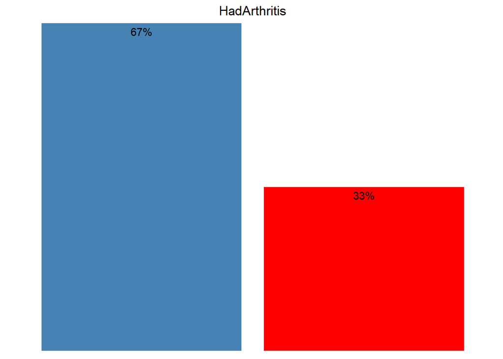

```
##
## [1] "% for HadDiabetes ( 10 )"
##
##        0        1
## 86.11009 13.88991
## [[1]]
```

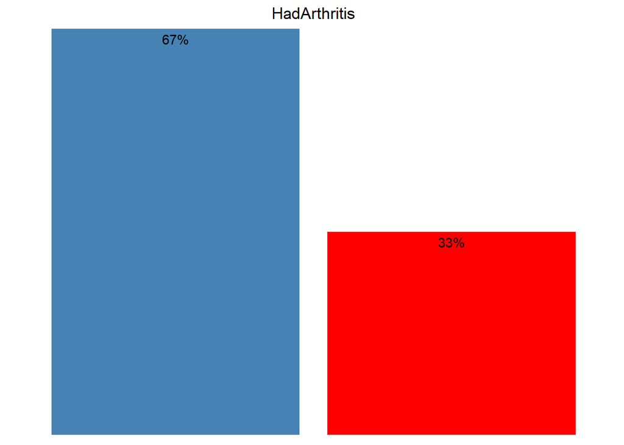

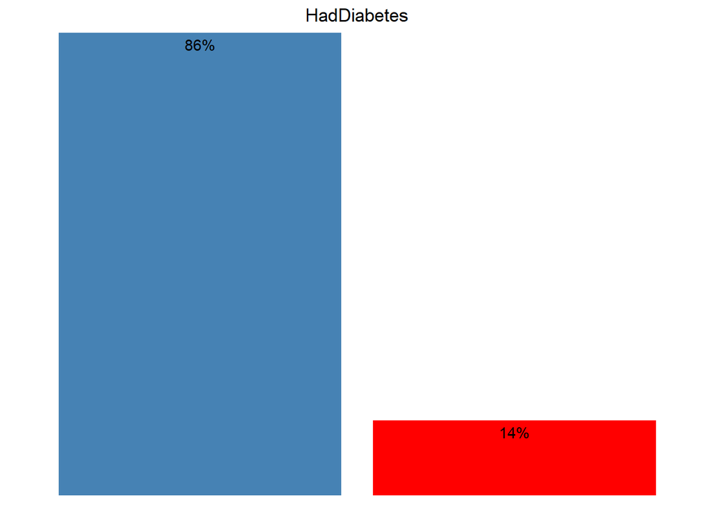

```r
library(ggplot2)
p <- list()
for (i in 10:19) {
  print(paste("% for", colnames(df)[i], "(", i-9, ")"))
  t <- table(df[,i])
  print(t/ nrow(df) * 100)
  #barplot(table(df[,i]), col = c("red", "blue"), axes = FALSE, main=colnames(df[i]))
  p[[i-9]] <-  ggplot(data.frame(table(df[,i])), aes(x = Var1, y = Freq)) +
    geom_bar(stat = "identity", fill = c("steelblue", "red") ) +
    geom_text(aes(label = paste0(round(Freq/sum(Freq)*100), "%")), vjust = 1.5) +
    scale_x_discrete(limits = c("0", "1"), labels = NULL) +
    scale_y_continuous(limits = c(0, max(table(df[,i]))), expand = c(0, 0), labels = NULL) +
    theme(axis.line = element_blank(),
          axis.text.x = element_blank(),
          axis.text.y = element_blank(),
          axis.ticks = element_blank(),
          axis.title.x = element_blank(),
          axis.title.y = element_blank(),
          panel.grid = element_blank(),
          panel.border = element_blank(),
          panel.background = element_blank(),
          plot.title = element_text(hjust = 0.5)) +
    labs(title = colnames(df[i]))
  print(p)
}
```

```r
#library(gridExtra)
#grid.arrange(grobs = p, ncol = 2)
```

We can clearly see the is not very well balanced, but as this is a first aproach and I really want to test it with clustering. I will first try this way and then I will only balance for “HadArtritis” (as is the one that will have more rows when balanced) and then compare with the “unbalanced” models.

Now using a for loop we can make a logistic regression for each disease. I decided to include all the other variables, because in some cases a disease can also be the consequence of another one. Examples: heart attack, angina and stroke are blood circulation related. Asthma and COPD are both respiratory/lung diseases.

```r
glm_list <- list()

for (i in 10:19) {
  formula <- as.formula(paste(colnames(df)[i]," ~ ."))

  glm_list[[i-9]] <- glm(formula, data = df, family = binomial)

  print(paste("GLM for", colnames(df)[i], "(", i-9, ")"), sep="")

  glm_summary <- summary(glm_list[[i-9]])
  glm_summary$coefficients <- glm_summary$coefficients[order(glm_summary$coefficients[,4]),]
  print(glm_summary)
}
```

```
## [1] "GLM for HadHeartAttack ( 1 )"
##
## Call:
## glm(formula = formula, family = binomial, data = df)
##
## Coefficients:
##                                                      Estimate Std. Error
## HadAngina                                           2.3471517  0.0173403
## HadStroke                                           0.9179849  0.0228513
## AgeCategory                                         0.1717458  0.0038283
## Gender                                              0.7028322  0.0221374
## GeneralHealth                                      -0.2714484  0.0094292
## ChestScan                                           0.4399933  0.0176147
## HadDiabetes                                         0.3527227  0.0181937
## SmokerStatus                                        0.2582608  0.0166477
## RemovedTeeth                                        0.2564427  0.0179334
## (Intercept)                                        -3.7710128  0.2727551
## ECigaretteUsage                                    -0.1767773  0.0191693
## AlcoholDrinkers                                    -0.1492353  0.0167353
## HadCOPD                                             0.1882514  0.0221588
## TetanusLast10Tdap                                  -0.1600447  0.0227432
## LastCheckupTime                                     0.0747027  0.0106167
## BlindOrVisionDifficulty                             0.1542638  0.0270764
## FluVaxLast12                                       -0.0999827  0.0177445
## SleepHours                                         -0.0243093  0.0046127
## HadKidneyDisease                                    0.1293277  0.0257301
## PhysicalActivities                                 -0.0876429  0.0176707
## HadSkinCancer                                      -0.1126991  0.0239509
## HeightInMeters                                     -0.6274738  0.1577867
## DifficultyDressingBathing                          -0.1203190  0.0332651
## HadArthritis                                        0.0596197  0.0170569
## RaceEthnicityCategoryBlack only, Non-Hispanic      -0.1754044  0.0512527
## PneumoVaxEver                                      -0.0551306  0.0183129
## RaceEthnicityCategoryMultiracial, Non-Hispanic      0.2027491  0.0673527
## DifficultyWalking                                   0.0565294  0.0210771
## WeightInKilograms                                   0.0033225  0.0013414
## BMI                                                -0.0100857  0.0041630
## HadDepressiveDisorder                               0.0440370  0.0217258
## CovidPos                                           -0.0371361  0.0186675
## MentalHealthDays                                    0.0019550  0.0010362
```

[output cut: 1014 more lines]

```
## State                                               -1.333 0.182465
## SleepHours                                          -1.007 0.313780
## HIVTesting                                          -0.807 0.419892
## SmokerStatus                                        -0.751 0.452530
## DifficultyConcentrating                              0.063 0.949804
## ---
## Signif. codes:  0 '***' 0.001 '**' 0.01 '*' 0.05 '.' 0.1 ' ' 1
##
## (Dispersion parameter for binomial family taken to be 1)
##
##     Null deviance: 343357  on 426042  degrees of freedom
## Residual deviance: 282742  on 425999  degrees of freedom
## AIC: 282830
##
## Number of Fisher Scoring iterations: 6
```

Now that all models are calculated we can check the impact of the race on all the diseases looking at its p value.

**( 1 ) GLM for HadHeartAttack:**

Mainly it can be related to the patient physic condition, but the firsts ethnicities to suffer it are black and multiracial. In the other hand hispanic and white are almost not related to it.

**( 2 ) GLM for HadAngina:**

Heavily influenced by previous heart attacks, but affect in great measure to black people. White and hispanic has also a relevant p value, but much lower. Meanwhile other races and multiracial has practically no relation with it.

**( 3 ) GLM for HadStroke:**

As with angina, heavily influenced by heart attack. Impacts most on hispanic and black ethnicities and a little to multiracial. But white and other races seem to have no direct implication.

**( 4 ) GLM for HadAsthma:**

As previously stated is greatly related to COPD. Multiracial and other race have lower p values. White and above all black ethnicity have no influence on it.

**( 5 ) GLM for HadSkinCancer:**

The main influence is age, but all ethnic groups have a great probability to suffer it. Black, Hispanic and Other race have a negative and great impact on this disease, stating something we already know, darker skin can better resist UV rays. In the other hand white has positive great influence.

**( 6 ) GLM for HadCOPD:**

Heavily influenced by asthma and smokers. Hispanic, Other race and Black being the more relevant and White almost irrelevant.

**( 7 ) GLM for HadDepressiveDisorder:**

Being the only psychic illness it can be predicted very easy with MentalHealthDays. All ethnicities have lower p values for this one, but it’s striking how black (negative) and white (positive) have opposite estimate.

**( 8 ) GLM for HadKidneyDisease:**

As supposed is very influenced by also having diabetes. The regression can only make a strong prediction for black ethnicity, the other ones, specially, other race and white have virtually no effect.

**( 9 ) GLM for HadArthritis:**

Has a great influence by depression, meaning it is an illness with a heavy impact on your mental health. While the model can almost predict having the disease for every ethnicity, it is shocking how Hispanic and White have the same p values but with opposites estimate (Hispanic being negative).

**( 10 ) GLM for HadDiabetes:**

Other race, hispanic and black all have the minimum p value and a z value greater than 10.

In general we see that ethnicity it isn’t in the top half of the list for the diseases. GeneralHealth, Age and gender usually are more important (top 5/10 in most cases). But almost in every case we see some kind of “genetic” influence. Being specially relevant for skin cancer, where 4 of 5 ethnic groups are among the top 15 relevant variables from 44 including all the etnicities levels, when usually the first one appears after that same number (15).

As stated before now I will balance the dataset for “HadArtritis” by downsampling it and compare both models.

```r
set.seed(123)

min_samples <- min(table(df$HadArthritis))

df_balanced <- data.frame()

for(level in unique(df$HadArthritis)) {
  df_level <- df[df$HadArthritis == level, ]

  df_sample <- df_level[sample(nrow(df_level), min_samples), ]

  df_balanced <- rbind(df_balanced, df_sample)
}
print("Count for HadArthritis levels:")
```

```
## [1] "Count for HadArthritis levels:"
```

```r
table(df_balanced$HadArthritis)
```

```
##
##      0      1
## 141875 141875
```

Now with the new balanced dataset it is time to make another model and compare with the original.

```r
glm_balanced <- glm(HadArthritis ~ ., data = df_balanced, family = binomial)

print("GLM for HadArthritis balanced ( 11 )")
```

```
## [1] "GLM for HadArthritis balanced ( 11 )"
```

```r
glm_summary <- summary(glm_balanced)
glm_summary$coefficients <- glm_summary$coefficients[order(glm_summary$coefficients[,4]),]
print(glm_summary)
```

```
##
## Call:
## glm(formula = HadArthritis ~ ., family = binomial, data = df_balanced)
##
## Coefficients:
##                                                      Estimate Std. Error
## DifficultyWalking                                   0.7336674  0.0155397
## AgeCategory                                         0.2543665  0.0019608
## GeneralHealth                                      -0.1988636  0.0055041
## HadDepressiveDisorder                               0.4438486  0.0128289
## Gender                                             -0.3809506  0.0126232
## PhysicalHealthDays                                  0.0191187  0.0006450
## HadAsthma                                           0.3458622  0.0132257
## LastCheckupTime                                     0.1400611  0.0053964
## SleepHours                                         -0.0714054  0.0030996
## PneumoVaxEver                                       0.2259960  0.0106361
## (Intercept)                                        -3.2365891  0.1569929
## RemovedTeeth                                        0.1923713  0.0096497
## ChestScan                                           0.1952010  0.0098684
## SmokerStatus                                        0.1694579  0.0097951
## HIVTesting                                          0.1657986  0.0108261
## HadSkinCancer                                       0.2114828  0.0159254
## DifficultyConcentrating                             0.1991530  0.0168471
## DeafOrHardOfHearing                                 0.1824431  0.0160532
## PhysicalActivities                                  0.1089865  0.0114002
## AlcoholDrinkers                                     0.0922440  0.0097259
## CovidPos                                            0.0984305  0.0104868
## HadCOPD                                             0.1649975  0.0180135
## BMI                                                 0.0217044  0.0023731
## WeightInKilograms                                   0.0069667  0.0007661
## HadKidneyDisease                                    0.1985421  0.0221779
## RaceEthnicityCategoryHispanic                      -0.2558798  0.0302612
## RaceEthnicityCategoryWhite only, Non-Hispanic       0.1986944  0.0255158
## FluVaxLast12                                        0.0782034  0.0100719
## RaceEthnicityCategoryMultiracial, Non-Hispanic      0.2728735  0.0405743
## MentalHealthDays                                    0.0037373  0.0006679
## HadAngina                                           0.1120495  0.0209820
## DifficultyErrands                                  -0.0989162  0.0216410
## State                                               0.0010355  0.0002877
## HeightInMeters                                     -0.3016369  0.0909817
```

[output cut: 50 more lines]

```
## BlindOrVisionDifficulty                              1.863 0.062446 .
## HighRiskLastYear                                    -1.501 0.133427
## RaceEthnicityCategoryBlack only, Non-Hispanic        1.340 0.180114
## HadDiabetes                                         -0.791 0.429160
## ECigaretteUsage                                     -0.650 0.515544
## ---
## Signif. codes:  0 '***' 0.001 '**' 0.01 '*' 0.05 '.' 0.1 ' ' 1
##
## (Dispersion parameter for binomial family taken to be 1)
##
##     Null deviance: 393361  on 283749  degrees of freedom
## Residual deviance: 299512  on 283706  degrees of freedom
## AIC: 299600
##
## Number of Fisher Scoring iterations: 4
```

```r
print("GLM for HadArthritis unbalanced ( 12 )")
```

```
## [1] "GLM for HadArthritis unbalanced ( 12 )"
```

```r
glm_summary <- summary(glm_list[[9]])
glm_summary$coefficients <- glm_summary$coefficients[order(glm_summary$coefficients[,4]),]
print(glm_summary)
```

```
##
## Call:
## glm(formula = formula, family = binomial, data = df)
##
## Coefficients:
##                                                      Estimate Std. Error
## GeneralHealth                                      -0.1903273  0.0046738
## HadDepressiveDisorder                               0.4516615  0.0107875
## DifficultyWalking                                   0.7380827  0.0124843
## AgeCategory                                         0.2453016  0.0016982
## Gender                                             -0.3979480  0.0108109
## PhysicalHealthDays                                  0.0178631  0.0005239
## HadAsthma                                           0.3456244  0.0110825
## LastCheckupTime                                     0.1418907  0.0047679
## (Intercept)                                        -3.8579970  0.1337599
## SleepHours                                         -0.0726057  0.0026032
## PneumoVaxEver                                       0.2370474  0.0089789
## RemovedTeeth                                        0.1945269  0.0082492
## ChestScan                                           0.1917944  0.0083786
## SmokerStatus                                        0.1484133  0.0083060
## HIVTesting                                          0.1584012  0.0092735
## HadSkinCancer                                       0.2028097  0.0130166
## DifficultyConcentrating                             0.1884455  0.0139657
## DeafOrHardOfHearing                                 0.1615307  0.0130313
## PhysicalActivities                                  0.1161866  0.0095789
## HadKidneyDisease                                    0.2113426  0.0178806
## BMI                                                 0.0229594  0.0019932
## CovidPos                                            0.1013863  0.0089643
## AlcoholDrinkers                                     0.0917674  0.0082728
## WeightInKilograms                                   0.0069588  0.0006459
## HadCOPD                                             0.1400427  0.0145011
## FluVaxLast12                                        0.0819770  0.0086118
## RaceEthnicityCategoryHispanic                      -0.2462517  0.0261286
## RaceEthnicityCategoryWhite only, Non-Hispanic       0.1953790  0.0218216
## RaceEthnicityCategoryMultiracial, Non-Hispanic      0.2675031  0.0346993
## DifficultyErrands                                  -0.1075132  0.0175578
## HadAngina                                           0.0990223  0.0168418
## MentalHealthDays                                    0.0030059  0.0005602
## State                                               0.0011400  0.0002452
## HeightInMeters                                     -0.3236017  0.0775169
```

[output cut: 50 more lines]

```
## HadDiabetes                                         -2.549 0.010817 *
## HighRiskLastYear                                    -2.510 0.012068 *
## RaceEthnicityCategoryOther race only, Non-Hispanic  -2.422 0.015440 *
## BlindOrVisionDifficulty                              1.915 0.055519 .
## ECigaretteUsage                                     -1.089 0.275942
## ---
## Signif. codes:  0 '***' 0.001 '**' 0.01 '*' 0.05 '.' 0.1 ' ' 1
##
## (Dispersion parameter for binomial family taken to be 1)
##
##     Null deviance: 542171  on 426042  degrees of freedom
## Residual deviance: 418308  on 425999  degrees of freedom
## AIC: 418396
##
## Number of Fisher Scoring iterations: 5
```

We can see the results differ a bit, but not so much. Hispanic, White only and Multiracial have almost exact results. Other race and Black seems to interchange values. Taking into consideration the “random” nature of any sampling process I do not think the extra effort of making a balanced dataset for every disease is worth it.